# jyang32_HW_8

June Yang

3/6/2020

## 0.1 Read data

```r
usa_death_1x1 <- read.table("Deaths_1x1.txt", skip = 2, header = TRUE, stringsAsFactors = FALSE)
head(usa_death_1x1,6)
```

```
##   Year Age   Female     Male     Total
## 1 1933   0 52615.77 68438.11 121053.88
## 2 1933   1  8917.13 10329.16  19246.29
## 3 1933   2  4336.92  5140.05   9476.97
## 4 1933   3  3161.59  3759.88   6921.47
## 5 1933   4  2493.84  2932.59   5426.43
## 6 1933   5  2139.87  2537.53   4677.40
```

```r
class(usa_death_1x1$Age)
```

```
## [1] "character"
```

```r
usa_death_1x1$Age <- as.integer(usa_death_1x1$Age)
```

I’ve chosen the United States as my country of interest. US is a country of “50 states, a federal district, five self-governing terriroris and various possessions” (wikipedia). The country has a population of 327.2 million as of 2018 , and has a gross domestic product of 19.39 trillion USD in 2017 (US Census Bureau). The 2010 census show that 72% of the US population are white.

Data is from the [Human Mortality Database](https://www.mortality.org). According to the website, data on United Sates come from various sources including decennial population censuses, periodical vital statistics publications, Duke Univeristy (who obtained data from National Center for Health Statistics), ICPSR, as well as CDC. Data table downloaded and used here contains annual US mortality data from 1933 to 2017. It has 9435 observations and has variables year, age, number of female death, number of male death and total death.

## 0.2 brief analysis of data

```r
usa_death_1x1 <- usa_death_1x1 %>%
  mutate(sexratio = Male/Female)

head(usa_death_1x1,20)
```

```
##    Year Age   Female     Male     Total sexratio
## 1  1933   0 52615.77 68438.11 121053.88 1.300715
## 2  1933   1  8917.13 10329.16  19246.29 1.158350
## 3  1933   2  4336.92  5140.05   9476.97 1.185184
## 4  1933   3  3161.59  3759.88   6921.47 1.189237
## 5  1933   4  2493.84  2932.59   5426.43 1.175934
## 6  1933   5  2139.87  2537.53   4677.40 1.185834
## 7  1933   6  1939.70  2337.76   4277.46 1.205217
## 8  1933   7  1760.47  2163.90   3924.37 1.229160
## 9  1933   8  1602.20  2015.97   3618.17 1.258251
## 10 1933   9  1464.88  1893.96   3358.84 1.292911
## 11 1933  10  1357.91  1805.52   3163.43 1.329632
## 12 1933  11  1318.90  1781.24   3100.14 1.350550
## 13 1933  12  1357.26  1828.76   3186.02 1.347391
## 14 1933  13  1472.99  1948.10   3421.09 1.322548
## 15 1933  14  1666.09  2139.25   3805.34 1.283994
## 16 1933  15  1923.01  2388.83   4311.84 1.242235
## 17 1933  16  2189.59  2643.37   4832.96 1.207244
## 18 1933  17  2452.27  2889.52   5341.79 1.178304
## 19 1933  18  2711.06  3127.25   5838.31 1.153516
## 20 1933  19  2965.97  3356.57   6322.54 1.131694
```

```r
mean(usa_death_1x1$sexratio)
```

```
## [1] 1.374373
```

## 0.3 text with embedded data

On average, male to female death ratio is 1.3743725.

## 0.4 hyperlink

Data is downloaded from [Human Mortality Database](https://www.mortality.org).

## 0.5 table

```r
table(usa_death_1x1$Age)
```

```
##
##   0   1   2   3   4   5   6   7   8   9  10  11  12  13  14  15  16  17
##  85  85  85  85  85  85  85  85  85  85  85  85  85  85  85  85  85  85
##  18  19  20  21  22  23  24  25  26  27  28  29  30  31  32  33  34  35
##  85  85  85  85  85  85  85  85  85  85  85  85  85  85  85  85  85  85
##  36  37  38  39  40  41  42  43  44  45  46  47  48  49  50  51  52  53
##  85  85  85  85  85  85  85  85  85  85  85  85  85  85  85  85  85  85
##  54  55  56  57  58  59  60  61  62  63  64  65  66  67  68  69  70  71
##  85  85  85  85  85  85  85  85  85  85  85  85  85  85  85  85  85  85
##  72  73  74  75  76  77  78  79  80  81  82  83  84  85  86  87  88  89
##  85  85  85  85  85  85  85  85  85  85  85  85  85  85  85  85  85  85
##  90  91  92  93  94  95  96  97  98  99 100 101 102 103 104 105 106 107
##  85  85  85  85  85  85  85  85  85  85  85  85  85  85  85  85  85  85
## 108 109
##  85  85
```

## 0.6 plot

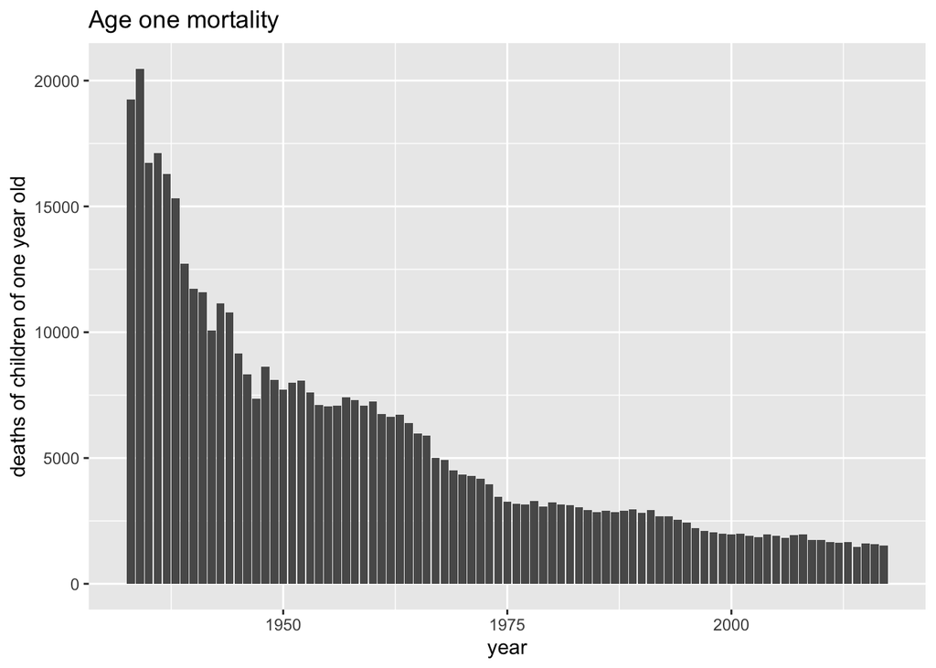

```r
age1 <- usa_death_1x1 %>% filter(Age == 1)
ggplot(data = age1, aes(x = Year, y = Total)) +
    geom_bar(stat = "identity") +
    ylab("deaths of children of one year old") +
    xlab("year") +
  ggtitle("Age one mortality")
```